# Ingredients List

Grinnel College

## Ingredients for use in Data Science Recipes

There are lots of data science recipes, but many of them are created from a common set of ingredients. We can spend more or less time on becoming familiar with these ingredients depending on

- The recipies you are interested in (emphasize most useful)
- The ingredients you are already feel comfortable with (avoid the most familiar)

## Graphics

### Packages: `ggformula`, `mosaic`

Plots like this are simple to make in R:

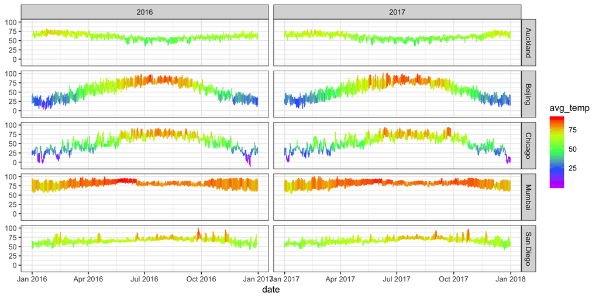

## Graphics

### Packages: `ggformula`, `mosaic`

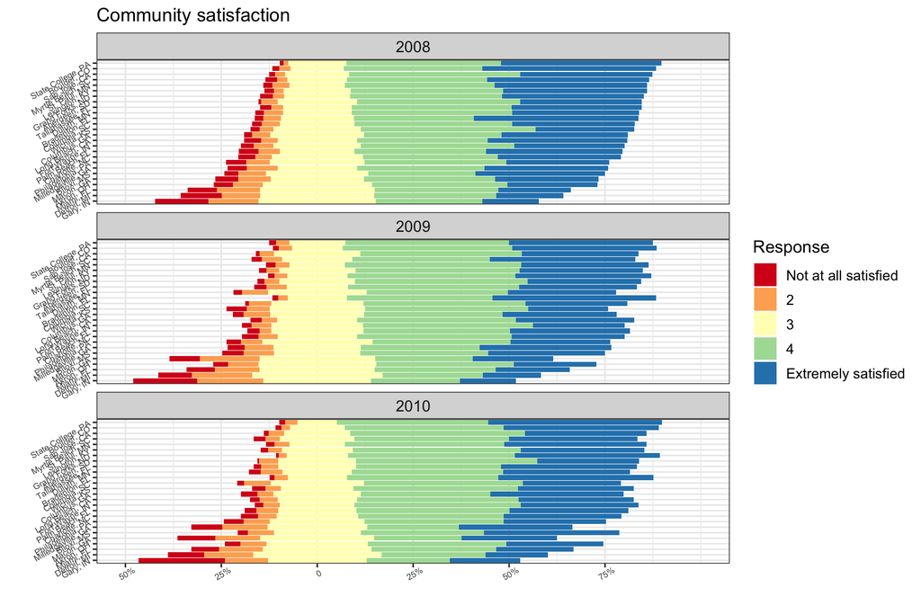

## Tidy Data and Data Wrangling

### Packages: `dplyr`, `tidyr`, etc.

Often we need to transform data into the proper format for analysis or graphics.

Tidy data:

- rows = observational units/cases/subjects
- columns = variables
- no exceptions, no "extras" (units, summaries, comments, meta-data, etc.)

## Data scraping

### Packages: `rvest`

- Lots of data available online
- May require some work to put a in the proper format (wrangling)

## Importing your own data

### Packages: `readr`, `googlesheets`, `readxl`, `haven`

R is capable of reading data in a wide variety of formats

- general-purpose formats: csv, tsv, fixed width
- data from other software: Excel, Google spreadsheets, SAS, SPSS
- databases: MySQL, MS SQLServer, etc.
- specialized data fromats: shape files for maps, FASTA files for genetics, etc.

If you have data you want to use in R, we can help you get it into R.

## Reporting

### Packages: `rmarkdown`, `bookdown`, `blogdown`, `knitr`, `flexdashboard`, etc.

RStudio provides a rich set of authoring tools to produce static and dynamic documents in a variety of formats (HTML, PDF, Word)

- [RStudio quick tour](https://rmarkdown.rstudio.com/authoring_quick_tour.html)
- [flexdashboard examples](https://rmarkdown.rstudio.com/flexdashboard/examples.html)

[figure not shown]

## Reporting

### Packages: `rmarkdown`, `bookdown`, `blogdown`, `knitr`, `flexdashboard`, etc.

R code and output can be included as well.

[figure not shown]

## Tutorials – run R code in a webpage

### Packages: `learnr`

- We will see several examples of this in the "Shop" part of the workshop.
- These are **not difficult to make** – use the same system as report creation (Rmd).

## Websites

### rstudio.cloud + GitHub

Websites can also be created using RMarkdown.

- The website for this workshop was done in RMarkdown
- These slides were, too.

GitHub can be used to host the website.

## GitHub

RStudio has excellent support for GitHub more generally. Great for

- maintaining your own work
- student projects
- creating R packages and making them available to others

## Maps

### Packages: `leaflet`

- More info from RStudio: [webinar](https://www.rstudio.com/resources/videos/mapping-in-r-with-leaflet/), [tutorial](https://rstudio.github.io/leaflet/)

[interactive chart not shown]

## Maps

### Packages: `ggformula`, `maps`, `sf`

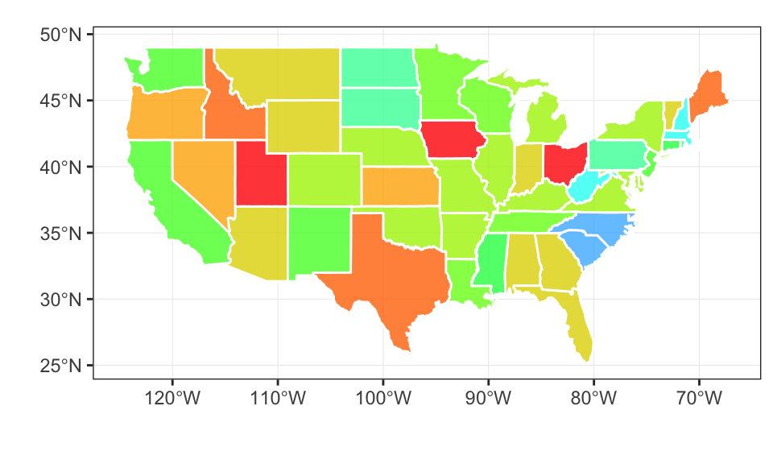

## Apps – interactivity, but no visible code

### Packages: `shiny`, `shinydocs`

- These generally take a bit more work to program, but this is doable.
- Great for producing data explorations that don't require users to know any R.
- A few examples
  - [Nick Horton's SAT app](https://r.amherst.edu/apps/nhorton/sat)
  - [Randy's Confidence Interval app](http://rsconnect.calvin.edu/CIs/)
  - [StatPREP examples](https://statprep.github.io/Workshops_2018/LittleApps/little_apps.html)
  - [RStudio Shiny Gallery](https://shiny.rstudio.com/gallery/)

## "Advanced" R

Don't let "advanced" scare you off. They are things that many people don't get around to learning early on, but they are not terribly difficult.

- Writing Functions
- [Creating Packages](http://r-pkgs.had.co.nz/)
- How the R language works (inspecting objects, avoiding inefficient "loops", using C++ inside R, etc.)
- Hadley Wickham's [Advanced R (online) book](http://adv-r.had.co.nz/)

## Modeling – Don't forget Statistics!

### Packages: many

R can fit an incredibly wide range of statistical models.

- Linear regression (and generalizations)
- Machine Learning
- Simulation-based methods (Bootstrap, Randomization, Validation methods)
- Bayesian methods
- etc, etc, etc